# Transformación de Datos

Gener Aviles-R

March 14, 2017

## Considering the figure, please answer the following questions:

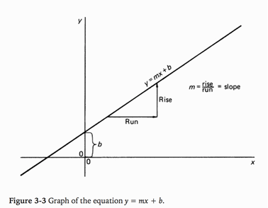

### 1. Which of the following formulas define $y$ as a linear function of $x$ ($m$ and $b$ are constants)?

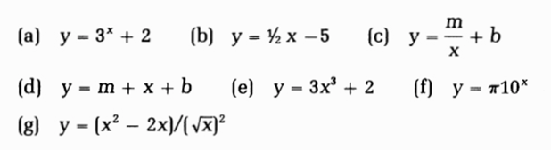

#### Graficación de las funciones

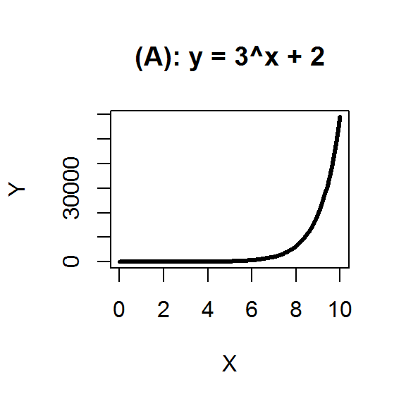

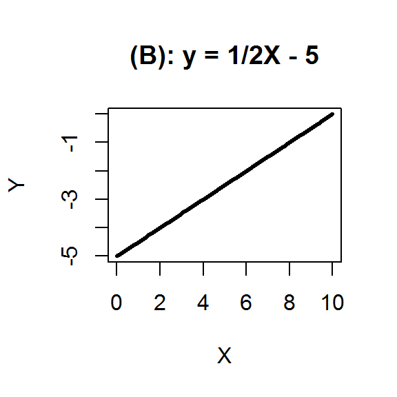

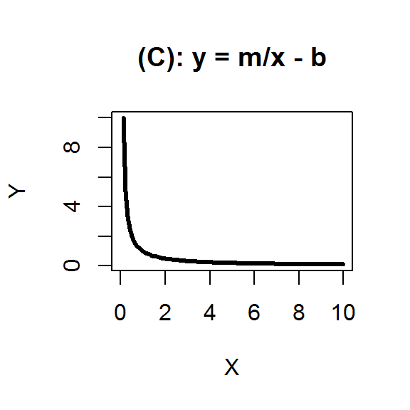

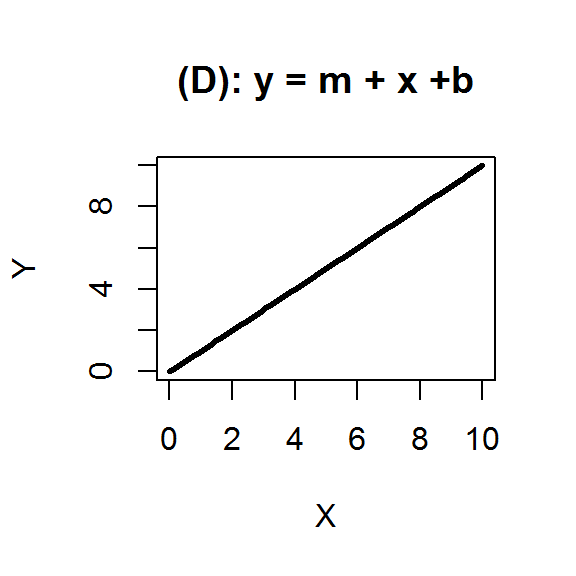

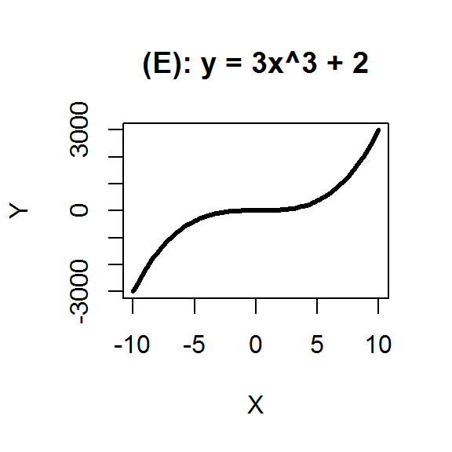

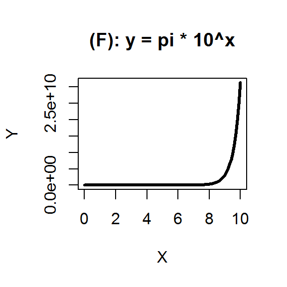

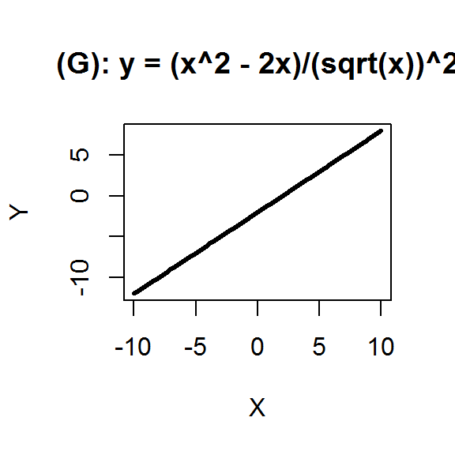

#### Respuesta

Basados en las graficaciones podemos ver que las ecuaciones lineales son las de los incisos:

- B
- D
- G

### 2. A straight line passes through the points $(3,5)$ and $(4,7)$. use these points to find a rise and corresponding run, the slope of the line, and the $y$ intercept $b$.

Para realizar éste ejercicio se utilizaremos la **ecuación de la recta** y la **forma punto pendiente**.

La fórmula de la ecuación de la recta es
$$y = mx+b$$
donde:

- $y$ = el valor en ejes de las Y.
- $m$ = la pendiente de la recta.
- $x$ = valor en ejes de las x.
- $b$ = coeficiente de posición, además de ser el número en que la recta corta el eje de las coordenadas.

La fórmula para encontrar el punto faltante en una gráfica es como sigue:
$$y-y_1 = m(x-x_2)$$
donde:
$$m = \frac{y_2-y_1}{x_2-x_1}$$
Substituyendo para encontrar el valor de $m$ y, eventualmente, el de $b$, tenemos:
$$m = \frac{(7)-(5)}{(4)-(3)} = \frac{2}{1} = 2$$
Ahora, substituyendo el valor de $m$ en la fórmula de punto pendiente:
$$y-(5) = 2\{x-(3)\}$$
$$y = 2x-1 \space \therefore$$
$$m = 2 \text{ y }b = -1$$

## For convenience in distinguishing the dependent variable (usually called $y$) in the following problems, we shall use the capital letter $B$, $C$, $D$, $E$ and $F$ instead of $y$.

In each of these problems a precise relation exists between two variables. Find the relation. Trnasform the $x$ variable in each problem to get the points on a straight line.

### Problema 3:

| B | 3 | 6 | 11 | 18 | 27 | 38 | 51 |
| --- | --- | --- | --- | --- | --- | --- | --- |
| x | 1 | 2 | 3 | 4 | 5 | 6 | 7 |

#### Relación inicial de variables:

**Creando los objetos necesarios en R y visualización inicial:**

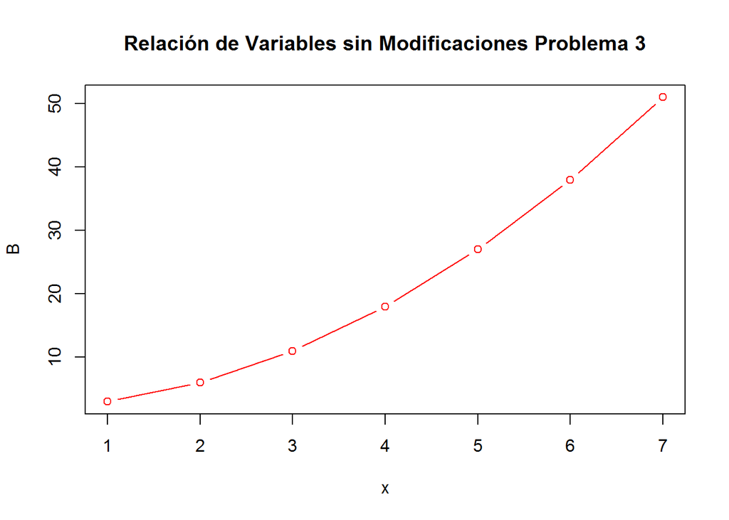

```r
B <- c(3,6,11,18,27,38,51)
x <- c(1,2,3,4,5,6,7)

plot(x, B,
     main = "Relación de Variables sin Modificaciones Problema 3",
     type = "b",
     col = "red")
```

#### P3 Exploración de Transformaciones de Datos más Comunes

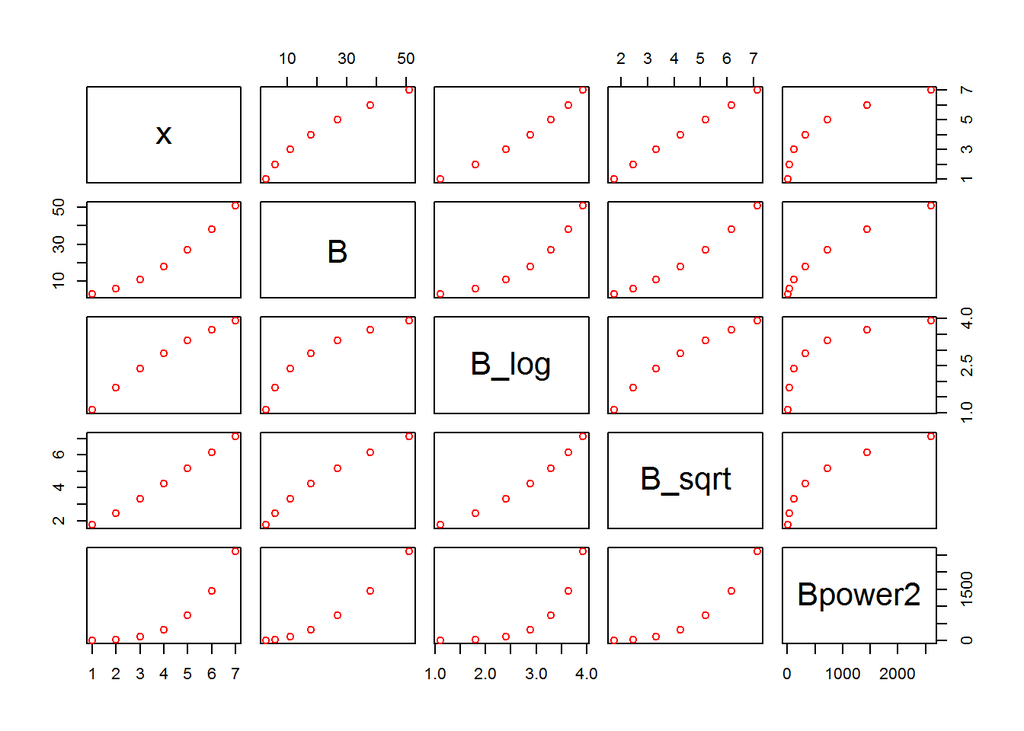

#### P3 Respuesta óptima

Para éste problema, al reducción por **raíz cuadrada** produce el mejor resultado. Entonces desarrollamos una gráfica solo de ésta transformación.

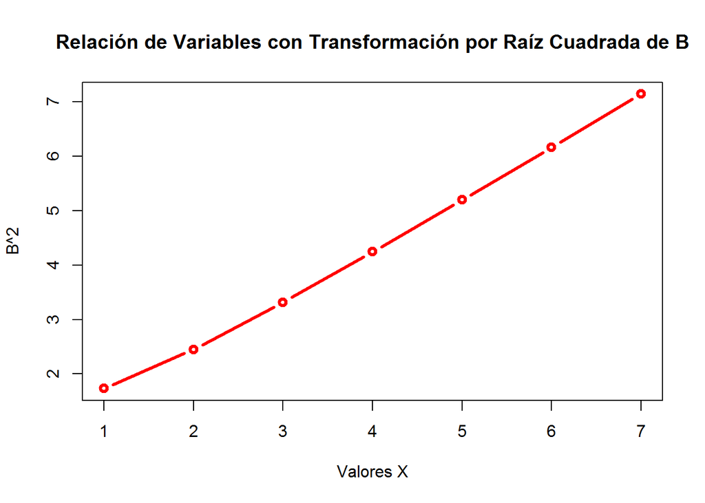

```r
plot(x, B_sqrt,
     type = "b",
     lwd = 3,
     col = "red",
     main = "Relación de Variables con Transformación por Raíz Cuadrada de B",
     xlab = "Valores X",
     ylab = "B^2")
```

### Problema 4

| C | 5 | 11 | 21 | 35 | 53 | 75 | 101 |
| --- | --- | --- | --- | --- | --- | --- | --- |
| x | 1 | 2 | 3 | 4 | 5 | 6 | 7 |

#### P4 Creando los objetos necesarios en R y visualización inicial:

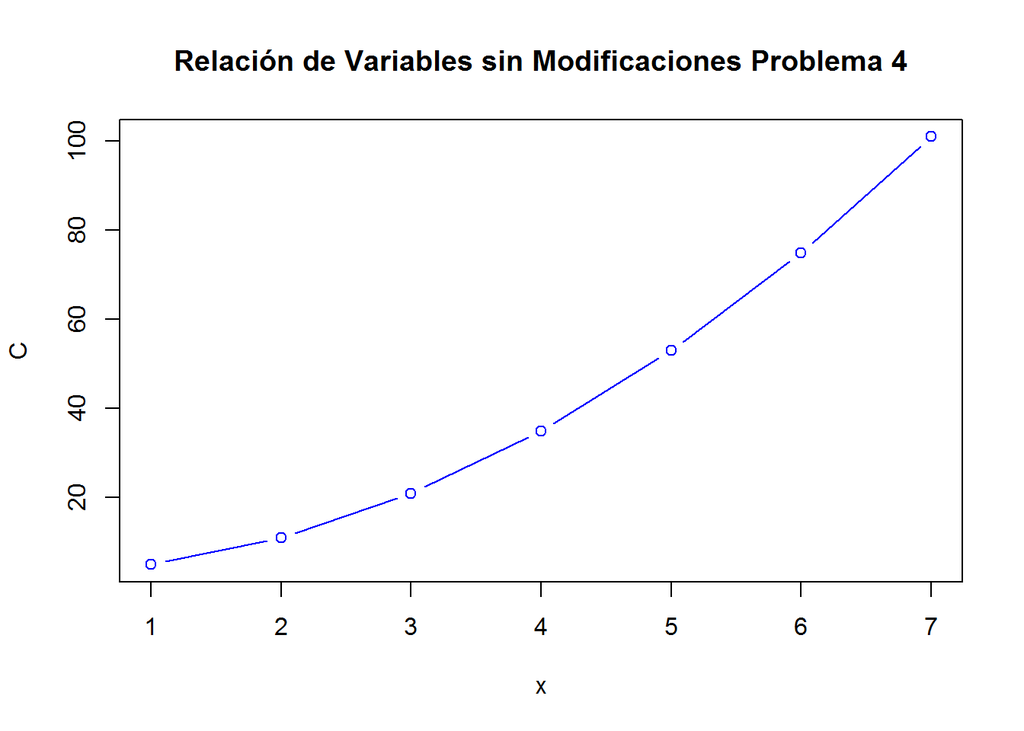

```r
C <- c(5,11,21,35,53,75,101)
x <- c(1,2,3,4,5,6,7)

cuatro <- data.frame(C,x)

plot(x, C,
     main = "Relación de Variables sin Modificaciones Problema 4",
     type = "b",
     col = "blue")
```

#### P4 Exploración de Transformaciones de Datos más Comunes

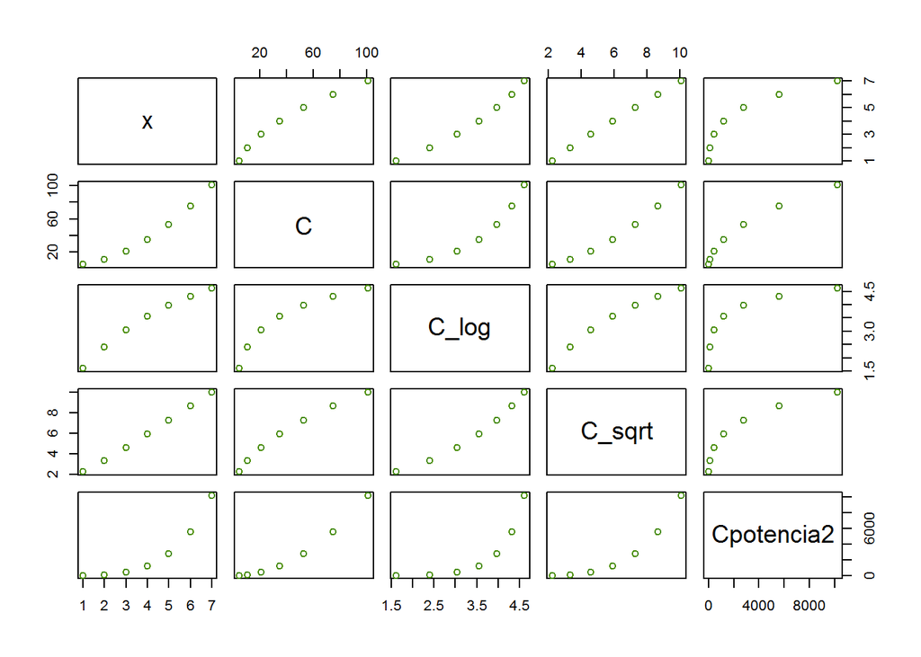

```r
##Raíz Cuadrada
C_sqrt <- sqrt(C)

#plot(x, B_sqrt, main = "Transformación con Raíz Cuadrada")
#lines(x,B_sqrt, type = "l")

##Potencia al cuadrado
Cpotencia2 <- C^2
#plot(x, Bpower2, main = "Transformación con Poder a la 2")
#lines(x,Bpower2, type = "l")

##Logaritmo
C_log <- log(C)
#plot(x, Bpower2, main = "Transformación por Logaritmos Naturales")
#lines(x,Bpower2, type = "l")

##Añadiendo todos los valores a una sola tabla
cuatro <- data.frame(x, C, C_log, C_sqrt, Cpotencia2)

##Una gráfica inicial
plot(cuatro,
     col = "chartreuse4")
```

#### P4 Respuesta óptima

Para éste problema, al reducción por **raíz cuadrada** produce el mejor resultado. Entonces desarrollamos una gráfica solo de ésta transformación.

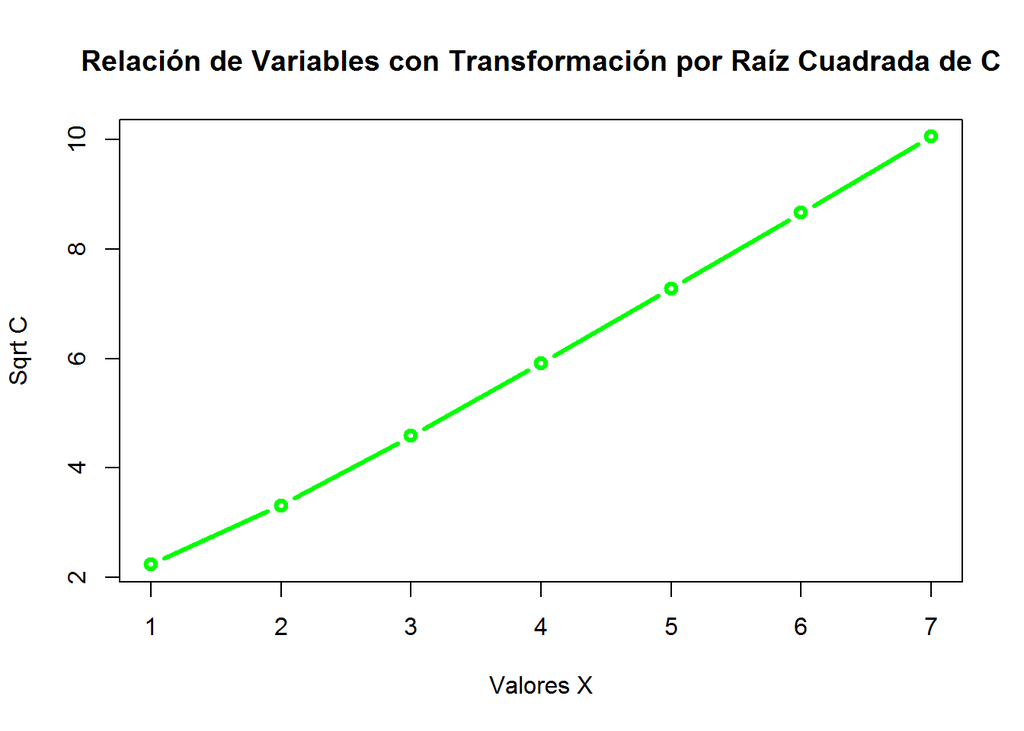

```r
plot(x, C_sqrt,
     type = "b",
     lwd = 3,
     col = "green",
     main = "Relación de Variables con Transformación por Raíz Cuadrada de C",
     xlab = "Valores X",
     ylab = "Sqrt C")
```

### Problema 5

| D | 1024 | 512 | 256 | 128 | 64 | 32 |
| --- | --- | --- | --- | --- | --- | --- |
| x | 1 | 2 | 3 | 4 | 5 | 6 |

#### P5 Creando los objetos necesarios en R y visualización inicial:

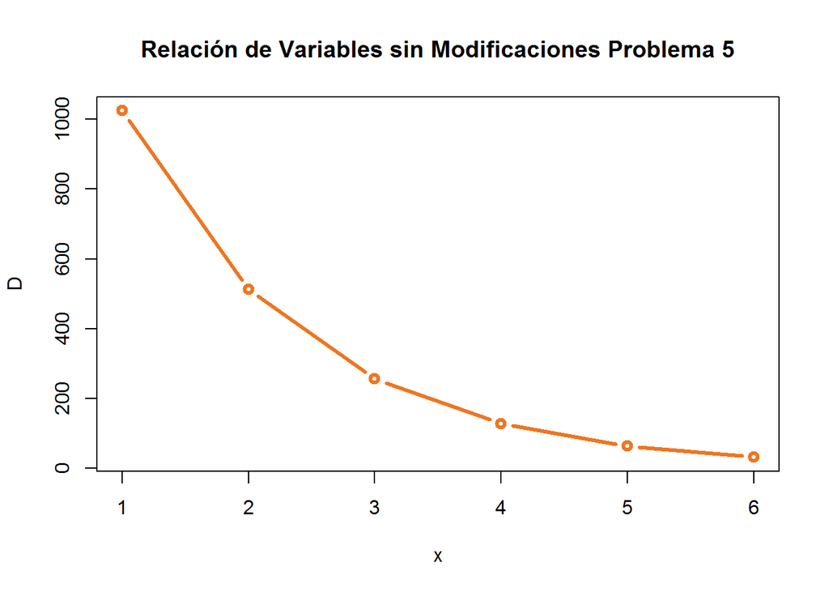

```r
D <- c(1024, 512, 256, 128, 64, 32)
x <- c(1,2,3,4,5,6)

cinco <- data.frame(D,x)

plot(x, D,
     type = "b",
     lwd = 3,
     col = "chocolate2",
     main = "Relación de Variables sin Modificaciones Problema 5")
```

#### P5 Exploración de Transformaciones de Datos más Comunes

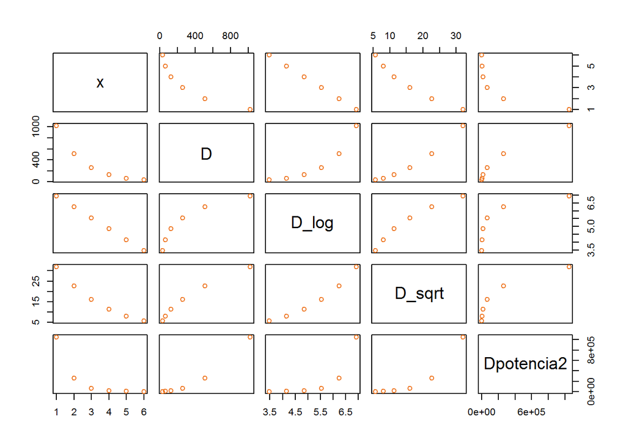

```r
##Raíz Cuadrada
D_sqrt <- sqrt(D)

#plot(x, B_sqrt, main = "Transformación con Raíz Cuadrada")
#lines(x,B_sqrt, type = "l")

##Potencia al cuadrado
Dpotencia2 <- D^2
#plot(x, Bpower2, main = "Transformación con Poder a la 2")
#lines(x,Bpower2, type = "l")

##Logaritmo
D_log <- log(D)
#plot(x, Bpower2, main = "Transformación por Logaritmos Naturales")
#lines(x,Bpower2, type = "l")

##Añadiendo todos los valores a una sola tabla
cinco <- data.frame(x, D, D_log, D_sqrt, Dpotencia2)

##Una gráfica inicial
plot(cinco,
     col = "chocolate2")
```

#### P5 Respuesta óptima

Para éste problema, al reducción por **logaritmo natural** produce el mejor resultado. Entonces desarrollamos una gráfica solo de ésta transformación.

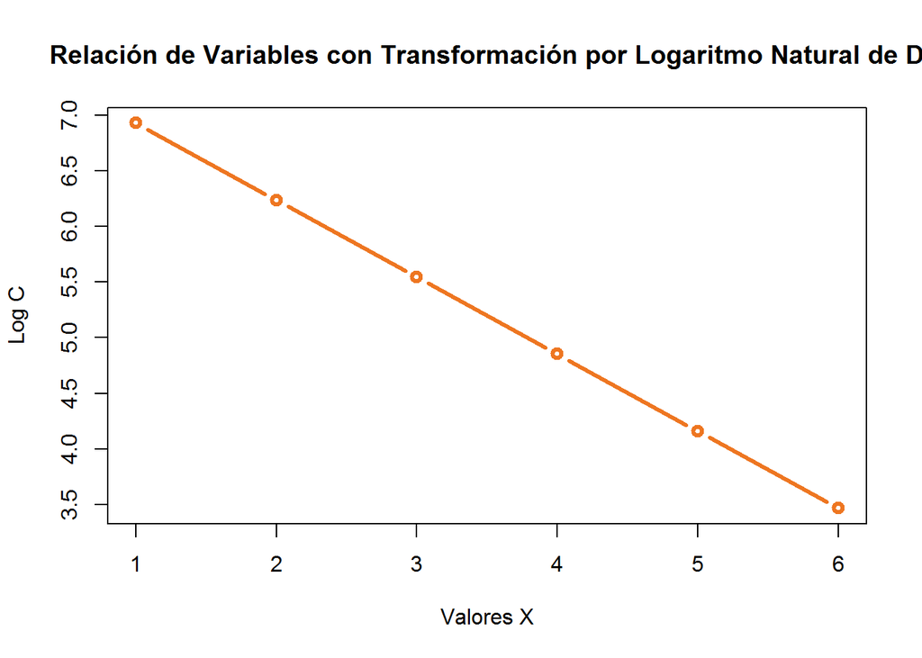

```r
plot(x, D_log,
     type = "b",
     lwd = 3,
     col = "chocolate2",
     main = "Relación de Variables con Transformación por Logaritmo Natural de D",
     xlab = "Valores X",
     ylab = "Log C")
```

### Problema 6

| E | 120 | 60 | 40 | 30 | 24 |
| --- | --- | --- | --- | --- | --- |
| x | 1 | 2 | 3 | 4 | 5 |

#### P6 Creando los objetos necesarios en R y visualización inicial:

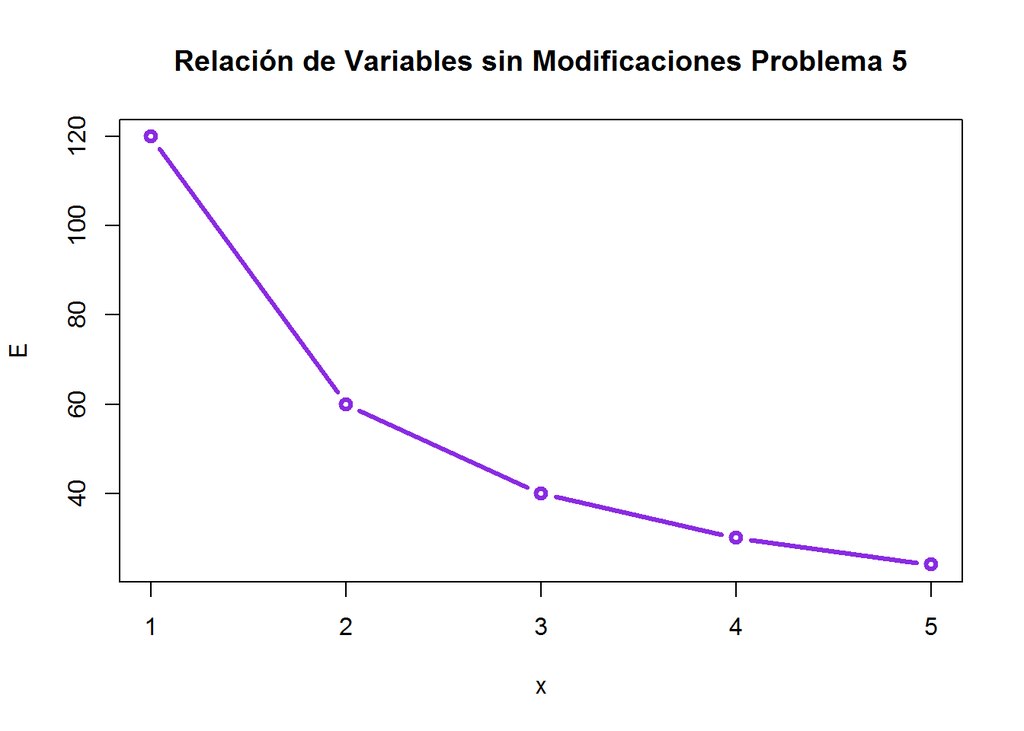

```r
E <- c(120,60,40,30,24)
x <- c(1,2,3,4,5)

cuatro <- data.frame(E,x)

plot(x, E,
     main = "Relación de Variables sin Modificaciones Problema 5",
     lwd = 3,
     type = "b",
     col = "blueviolet")
```

#### P6 Exploración de Transformaciones de Datos más Comunes

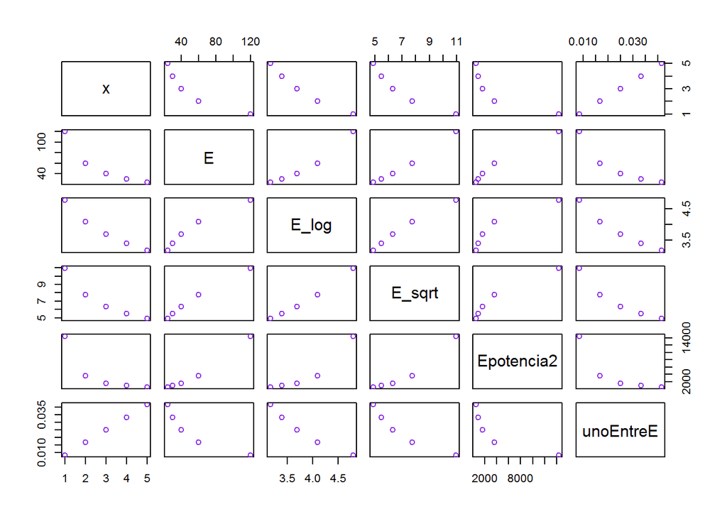

```r
##Raíz Cuadrada
E_sqrt <- sqrt(E)

#plot(x, B_sqrt, main = "Transformación con Raíz Cuadrada")
#lines(x,B_sqrt, type = "l")

##Potencia al cuadrado
Epotencia2 <- E^2
#plot(x, Bpower2, main = "Transformación con Poder a la 2")
#lines(x,Bpower2, type = "l")

##Logaritmo
E_log <- log(E)
#plot(x, Bpower2, main = "Transformación por Logaritmos Naturales")
#lines(x,Bpower2, type = "l")

##1/x

unoEntreE <- 1/E

##Añadiendo todos los valores a una sola tabla
seis <- data.frame(x, E, E_log, E_sqrt, Epotencia2, unoEntreE)

##Una gráfica inicial
plot(seis,
     col = "blueviolet")
```

#### P6 Respuesta óptima

Para éste problema, al reducción por **$1/E$** produce el mejor resultado. Entonces desarrollamos una gráfica solo de ésta transformación.

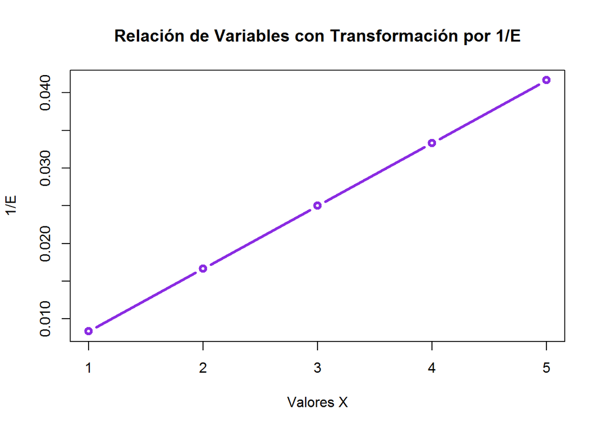

```r
plot(x, unoEntreE,
     type = "b",
     lwd = 3,
     col = "blueviolet",
     main = "Relación de Variables con Transformación por 1/E",
     xlab = "Valores X",
     ylab = "1/E")
```

### Problema 7

Encuentra la pendiente cuando $F$ es graficada contra $x^2$, después da la fórmula para $F$ y $x^2$.

| F | 0.283 | 0.785 | 1.54 | 2.54 |
| --- | --- | --- | --- | --- |
| x | 0.3 | 0.5 | 0.7 | 0.9 |

```r
#F <- c(0.283,0.785,1.54,2.54)
#x_1 <- c(0.3,0.5,0.7,0.9)
#xsqr <- x_1^2

#cuatro <- data.frame(E,x)

#plot(x, E,
 #    main = "Relación de Variables sin Modificaciones Problema 5",
  #   lwd = 3,
   #  type = "b",
    # col = "blueviolet")
```

### Problema 8

$$y = 4\pi x^2$$

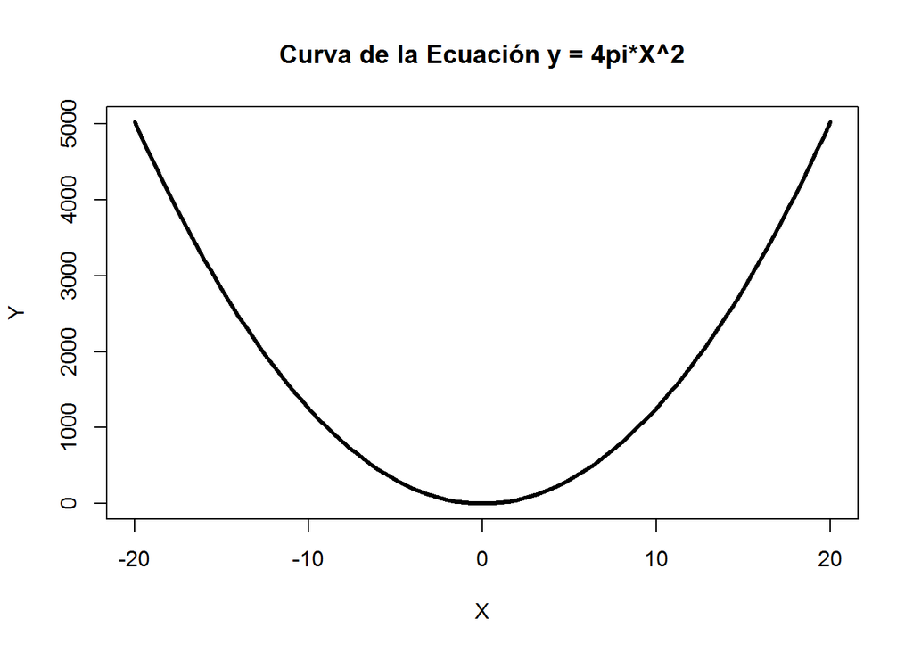

```r
eq = function(x){x^2*(pi*4)}
test8 <- curve(eq,
      from=-20, to=20,
      lwd = 3,
      main = "Curva de la Ecuación y = 4pi*X^2",
      xlab="X",
      ylab="Y")
```

Aplicando una transformación de datos por raíz cuadrada obtenemos la siguiente gráfica:

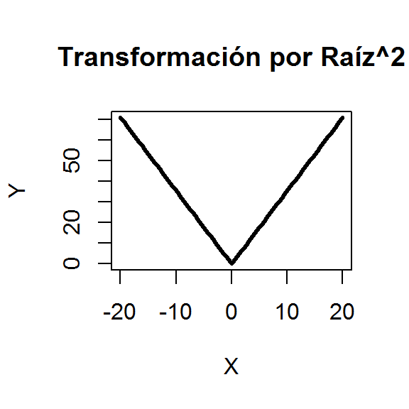

```r
plot(test8$x, sqrt(test8$y),
     type = "l",
     lwd = 3,
     main = "Transformación por Raíz^2",
     xlab = "X",
     ylab = "Y")
```

### Problema 9

$$y = 5x^3 - 10$$

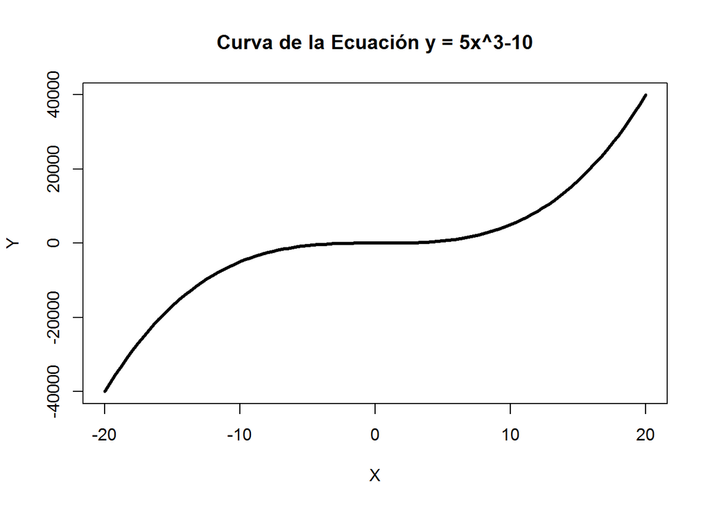

```r
eq = function(x){((x^3)*5)-10}
test9 <- curve(eq,
      from=-20, to=20,
      lwd = 3,
      main = "Curva de la Ecuación y = 5x^3-10",
      xlab="X",
      ylab="Y")
```

Aplicando una transformación de datos por raíz cúbica obtenemos la siguiente gráfica:

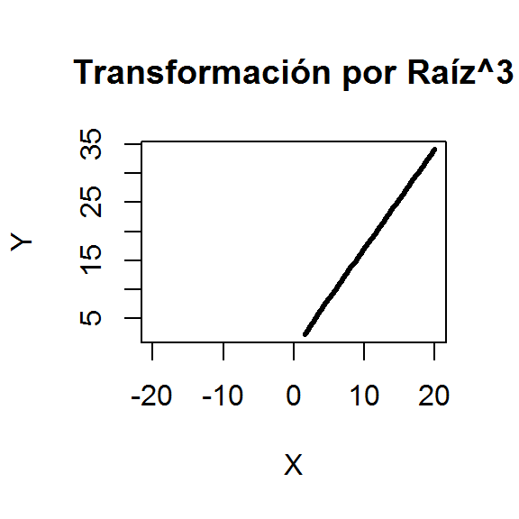

```r
plot(test9$x, (test9$y)^(1/3),
     type = "l",
     lwd = 3,
     main = "Transformación por Raíz^3",
     xlab = "X",
     ylab = "Y")
```

### Problema 10

$$y = \frac{3}{x^{1/2}}$$

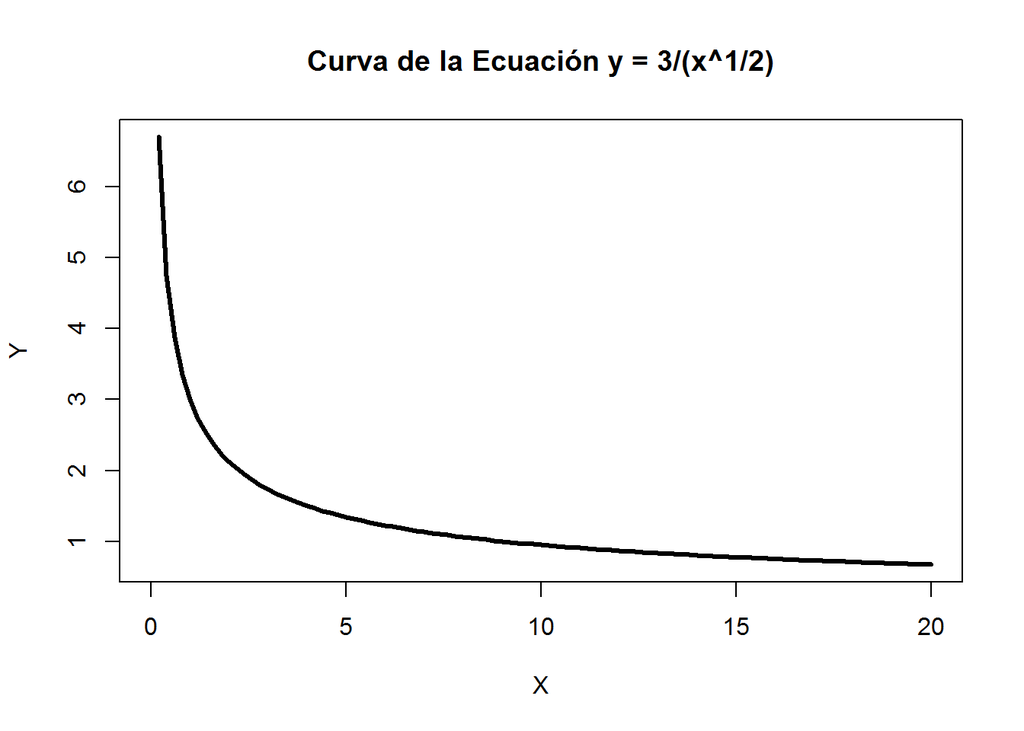

```r
eq = function(x){3/(x^(1/2))}
test10 <- curve(eq,
      from=0, to=20,
      lwd = 3,
      main = "Curva de la Ecuación y = 3/(x^1/2)",
      xlab="X",
      ylab="Y")
```

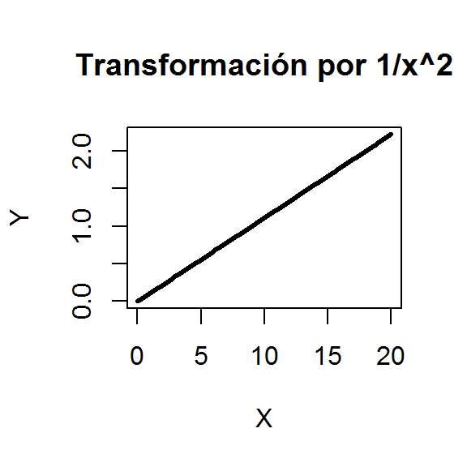

```r
plot(test10$x, 1/(test10$y)^2,
     type = "l",
     lwd = 3,
     main = "Transformación por 1/x^2",
     xlab = "X",
     ylab = "Y")
```

### Problema 11

$$y = 5(10^x)$$

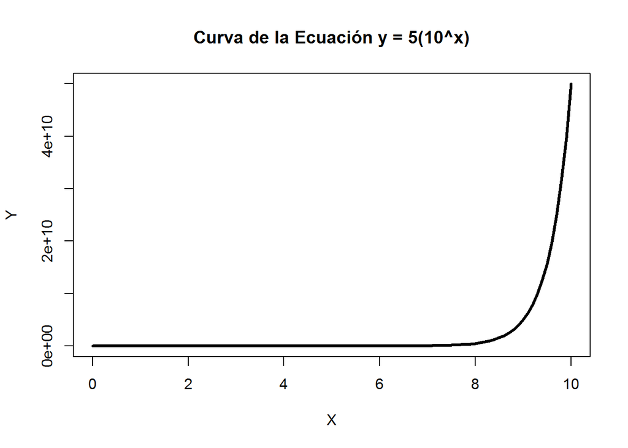

```r
eq = function(x){10^x * 5}
test11 <- curve(eq,
      from=0, to=10,
      lwd = 3,
      main = "Curva de la Ecuación y = 5(10^x)",
      xlab="X",
      ylab="Y")
```

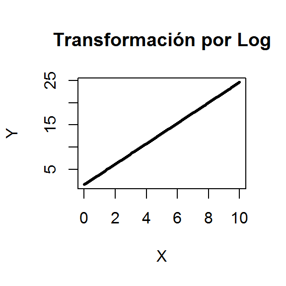

```r
plot(test11$x, log(test11$y),
     type = "l",
     lwd = 3,
     main = "Transformación por Log",
     xlab = "X",
     ylab = "Y")
```